# CAB420, DCNNs, Additional Script: Lots of ResNet Models

Dr Simon Denman (s.denman@qut.edu.au)

## What is this all about?

This is a script that will train, and save, a bunch of models on the datasets that we use most commonly in CAB420. A mix of models, with bottleneck and standard layouts and with different numbers of layers and network widths, wll be trained.

These will all a common set of functions to build our networks, so all networks will have similar topologies, just with different depths and different numbers of filters.

For completeness, results are shown for each model, however the main purpose of this script is really to just train and save models for later use. Please note that these models are not meant to achieve the best performance possible, but rather provide a variety of suitable doner networks, with different amounts of complexity, for later fine-tuning and adaptation. For example, MNIST or FashionMNIST models could be adapted to other tasks such as KMNIST as they share the same type of input data. Similarly, CIFAR could be adapted to tasks such as face recognition or person re-id (assuming that images are the correct shape). You could also use this example to borrow code to create your own networks.

Also note that this example was run on a GPU equipped desktop.

This example is heavily inspired by the keras example script [here](https://keras.io/examples/cifar10_resnet/)

```python
import os
import datetime
import numpy

import tensorflow as tf

from tensorflow import keras
from tensorflow.keras.layers import Dense, Conv2D, BatchNormalization, Activation
from tensorflow.keras.layers import AveragePooling2D, Input, Flatten
from tensorflow.keras import activations
from tensorflow.keras.regularizers import l2

from sklearn.metrics import confusion_matrix, ConfusionMatrixDisplay
import matplotlib.pyplot as plt

import pydot
import IPython
from IPython.display import SVG
from tensorflow.keras.utils import model_to_dot, plot_model

from tensorflow.keras.datasets import cifar10
from tensorflow.keras.callbacks import ModelCheckpoint

import cv2
```

## Network Building Functions

These are largely taken from the Keras example [here](https://keras.io/examples/cifar10_resnet/). They are adapted slightly to not actually specify an output, and allow a bit more configuration of the number of stages and size of the stages, but other than that are fairly faithful to the Keras example.

```python
def resnet_layer(inputs,
                 num_filters=16,
                 kernel_size=3,
                 strides=1,
                 activation='relu',
                 batch_normalization=True,
                 conv_first=True):
    """2D Convolution-Batch Normalization-Activation stack builder

    # Arguments
        inputs (tensor): input tensor from input image or previous layer
        num_filters (int): Conv2D number of filters
        kernel_size (int): Conv2D square kernel dimensions
        strides (int): Conv2D square stride dimensions
        activation (string): activation name
        batch_normalization (bool): whether to include batch normalization
        conv_first (bool): conv-bn-activation (True) or
            bn-activation-conv (False)

    # Returns
        x (tensor): tensor as input to the next layer
    """
    conv = Conv2D(num_filters,
                  kernel_size=kernel_size,
                  strides=strides,
                  padding='same',
                  kernel_initializer='he_normal',
                  kernel_regularizer=l2(1e-4))

    x = inputs
    if conv_first:
        x = conv(x)
        if batch_normalization:
            x = BatchNormalization()(x)
        if activation is not None:
            x = Activation(activation)(x)
    else:
        if batch_normalization:
            x = BatchNormalization()(x)
        if activation is not None:
            x = Activation(activation)(x)
        x = conv(x)
    return x


def resnet_v1(inputs, filters, num_res_blocks, pool_size):
    """ResNet Version 1 Model builder [a]

    Stacks of 2 x (3 x 3) Conv2D-BN-ReLU
    Last ReLU is after the shortcut connection.
    At the beginning of each stage, the feature map size is halved (downsampled)
    by a convolutional layer with strides=2, while the number of filters is
    doubled. Within each stage, the layers have the same number filters and the
    same number of filters.

    # Arguments
        inputs (layer):         the input tensor
        filters ([int]):        number of filters in each stage, length of list determines number of stages
        num_res_blocks (int):   number of residual blocks per stage
        pool_size (int):        size of the average pooling at the end

    # Returns
        output after global average pooling and flatten, ready for output
    """
    x = resnet_layer(inputs=inputs,
                     num_filters=filters[0])

    # Instantiate the stack of residual units
    for stack, filters in enumerate(filters):
        for res_block in range(num_res_blocks):
            strides = 1
            if stack > 0 and res_block == 0:  # first layer but not first stack
                strides = 2  # downsample
            y = resnet_layer(inputs=x,
                             num_filters=filters,
                             strides=strides)
            y = resnet_layer(inputs=y,
                             num_filters=filters,
                             activation=None)
            if stack > 0 and res_block == 0:  # first layer but not first stack
                # linear projection residual shortcut connection to match
                # changed dims
                x = resnet_layer(inputs=x,
                                 num_filters=filters,
                                 kernel_size=1,
                                 strides=strides,
                                 activation=None,
                                 batch_normalization=False)
            x = keras.layers.add([x, y])
            x = Activation('relu')(x)

    # Add classifier on top.
    # v1 does not use BN after last shortcut connection-ReLU
    x = AveragePooling2D(pool_size=pool_size)(x)
    y = Flatten()(x)

    return y


def resnet_v2(inputs, filters, num_res_blocks, pool_size):
    """ResNet Version 2 Model builder [b]

    Stacks of (1 x 1)-(3 x 3)-(1 x 1) BN-ReLU-Conv2D or also known as
    bottleneck layer
    First shortcut connection per layer is 1 x 1 Conv2D.
    Second and onwards shortcut connection is identity.
    At the beginning of each stage, the feature map size is halved (downsampled)
    by a convolutional layer with strides=2, while the number of filter maps is
    doubled. Within each stage, the layers have the same number filters and the
    same filter map sizes.

    # Arguments
        inputs (layer):         the input tensor
        filters ([int]):        number of filters in each stage, length of list determines number of stages
        num_res_blocks (int):   number of residual blocks per stage
        pool_size (int):        size of the average pooling at the end

    # Returns
        output after global average pooling and flatten, ready for output
    """

    x = resnet_layer(inputs=inputs,
                     num_filters=filters[0],
                     conv_first=True)

    # Instantiate the stack of residual units
    for stage, filters in enumerate(filters):
        num_filters_in = filters
        for res_block in range(num_res_blocks):
            activation = 'relu'
            batch_normalization = True
            strides = 1
            if stage == 0:
                num_filters_out = num_filters_in * 4
                if res_block == 0:  # first layer and first stage
                    activation = None
                    batch_normalization = False
            else:
                num_filters_out = num_filters_in * 2
                if res_block == 0:  # first layer but not first stage
                    strides = 2    # downsample

            # bottleneck residual unit
            y = resnet_layer(inputs=x,
                             num_filters=num_filters_in,
                             kernel_size=1,
                             strides=strides,
                             activation=activation,
                             batch_normalization=batch_normalization,
                             conv_first=False)
            y = resnet_layer(inputs=y,
                             num_filters=num_filters_in,
                             conv_first=False)
            y = resnet_layer(inputs=y,
                             num_filters=num_filters_out,
                             kernel_size=1,
                             conv_first=False)
            if res_block == 0:
                # linear projection residual shortcut connection to match
                # changed dims
                x = resnet_layer(inputs=x,
                                 num_filters=num_filters_out,
                                 kernel_size=1,
                                 strides=strides,
                                 activation=None,
                                 batch_normalization=False)
            x = keras.layers.add([x, y])

        num_filters_in = num_filters_out

    # Add classifier on top.
    # v2 has BN-ReLU before Pooling
    x = BatchNormalization()(x)
    x = Activation('relu')(x)
    x = AveragePooling2D(pool_size=pool_size)(x)
    y = Flatten()(x)
    return y
```

## Model Training, Evaluation and Saving

Simple function to:

- Create a checkpoint to save the best model
- Train the network
- Load the best model weights
- Save the whole model, architeture and best weights
- Plot the loss and accuracy grapsh
- Evaluate the best model on the training and testing sets

```python
def train_and_eval(model, x_train, y_train, x_test, y_test, filename, batch_size, epochs):

    checkpoint = ModelCheckpoint(filename, verbose=1, monitor='val_loss',save_best_only=True, mode='auto')

    history = model.fit(x_train, y_train,
                        batch_size=batch_size,
                        epochs=epochs,
                        validation_data=(x_test, y_test),
                        callbacks=[checkpoint])

    model.load_weights(filename)
    model.save(filename)

    fig = plt.figure(figsize=[30, 10])
    ax = fig.add_subplot(1, 3, 1)
    plt.plot(history.history['loss'], label='loss')
    plt.plot(history.history['accuracy'], label='accuracy')
    plt.plot(history.history['val_loss'], label='val_loss')
    plt.plot(history.history['val_accuracy'], label='val_accuracy')
    ax.legend()
    ax.set_title('Training Performance')


    ax = fig.add_subplot(1, 3, 2)
    pred = model.predict(x_train);
    indexes = tf.argmax(pred, axis=1)
    cm = confusion_matrix(y_train, indexes)
    c = ConfusionMatrixDisplay(cm, display_labels=range(10))
    c.plot(ax = ax)
    ax.set_title('Training')

    ax = fig.add_subplot(1, 3, 3)
    pred = model.predict(x_test);
    indexes = tf.argmax(pred, axis=1)
    cm = confusion_matrix(y_test, indexes)
    c = ConfusionMatrixDisplay(cm, display_labels=range(10))
    c.plot(ax = ax)
    ax.set_title('Testing')
```

## Some Global Constants

These are some constant values that we'll use in these models. Things like the batch size and number of epochs.

```python
batch_size = 128;
num_epochs = 10;
```

## Fashion MNIST Models

```python
(x_train, y_train), (x_test, y_test) = keras.datasets.fashion_mnist.load_data()
x_train = x_train.reshape(x_train.shape[0], 28, 28, 1).astype('float32') / 255.0
y_train = y_train.reshape(y_train.shape[0], 1)
x_test = x_test.reshape(x_test.shape[0], 28, 28, 1).astype('float32') / 255.0
y_test = y_test.reshape(y_test.shape[0], 1)
```

### ResNet v1, Small Model

[output not shown]

[output not shown]

```
Epoch 00001: val_loss improved from inf to 0.60339, saving model to resnet_v1_FashionMNIST_small.h5
```

```
Epoch 00002: val_loss improved from 0.60339 to 0.55834, saving model to resnet_v1_FashionMNIST_small.h5
Epoch 00003: val_loss improved from 0.55834 to 0.48682, saving model to resnet_v1_FashionMNIST_small.h5
Epoch 00004: val_loss did not improve from 0.48682
Epoch 00005: val_loss did not improve from 0.48682
Epoch 00006: val_loss improved from 0.48682 to 0.35811, saving model to resnet_v1_FashionMNIST_small.h5
Epoch 00007: val_loss did not improve from 0.35811
Epoch 00008: val_loss did not improve from 0.35811
Epoch 00009: val_loss did not improve from 0.35811
Epoch 00010: val_loss did not improve from 0.35811
```

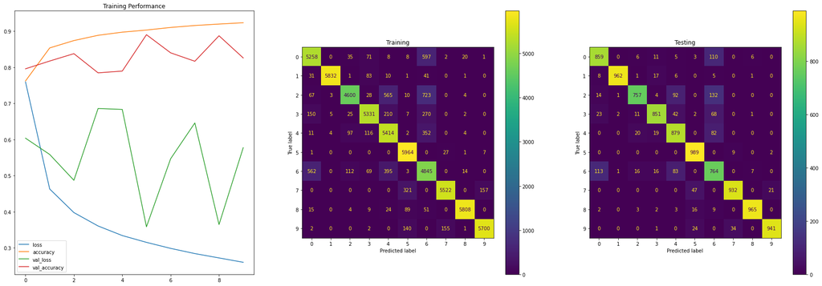

```python
inputs = Input(shape=(28, 28, 1, ), name='img')
x = resnet_v1(inputs, [16, 32], 2, 14)
output = Dense(10)(x)
model_cnn = keras.Model(inputs=inputs, outputs=output, name='simple_resnet_v1')
model_cnn.compile(loss=keras.losses.SparseCategoricalCrossentropy(from_logits=True),
              optimizer=keras.optimizers.RMSprop(),
              metrics=['accuracy'])
train_and_eval(model_cnn, x_train, y_train, x_test, y_test, 'resnet_v1_FashionMNIST_small.h5', batch_size, num_epochs)
```

### ResNet v1, Medium Model

```
Epoch 00001: val_loss improved from inf to 0.55614, saving model to resnet_v1_FashionMNIST_medium.h5
```

```
Epoch 00002: val_loss improved from 0.55614 to 0.53381, saving model to resnet_v1_FashionMNIST_medium.h5
Epoch 00003: val_loss improved from 0.53381 to 0.50293, saving model to resnet_v1_FashionMNIST_medium.h5
Epoch 00004: val_loss improved from 0.50293 to 0.40763, saving model to resnet_v1_FashionMNIST_medium.h5
Epoch 00005: val_loss improved from 0.40763 to 0.39116, saving model to resnet_v1_FashionMNIST_medium.h5
Epoch 00006: val_loss improved from 0.39116 to 0.33444, saving model to resnet_v1_FashionMNIST_medium.h5
Epoch 00007: val_loss did not improve from 0.33444
Epoch 00008: val_loss did not improve from 0.33444
Epoch 00009: val_loss did not improve from 0.33444
Epoch 00010: val_loss did not improve from 0.33444
```

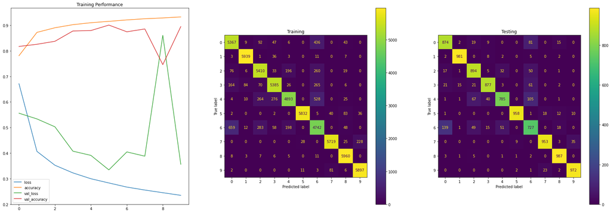

```python
inputs = Input(shape=(28, 28, 1, ), name='img')
x = resnet_v1(inputs, [8, 16, 32], 2, 7)
output = Dense(10)(x)
model_cnn = keras.Model(inputs=inputs, outputs=output, name='medium_resnet_v1')
model_cnn.compile(loss=keras.losses.SparseCategoricalCrossentropy(from_logits=True),
              optimizer=keras.optimizers.RMSprop(),
              metrics=['accuracy'])
train_and_eval(model_cnn, x_train, y_train, x_test, y_test, 'resnet_v1_FashionMNIST_medium.h5', batch_size, num_epochs)
```

### ResNet v1, Large Model

```
Epoch 00001: val_loss improved from inf to 0.56203, saving model to resnet_v1_FashionMNIST_big.h5
```

```
Epoch 00002: val_loss improved from 0.56203 to 0.52778, saving model to resnet_v1_FashionMNIST_big.h5
Epoch 00003: val_loss improved from 0.52778 to 0.52533, saving model to resnet_v1_FashionMNIST_big.h5
Epoch 00004: val_loss did not improve from 0.52533
Epoch 00005: val_loss improved from 0.52533 to 0.49712, saving model to resnet_v1_FashionMNIST_big.h5
Epoch 00006: val_loss improved from 0.49712 to 0.46198, saving model to resnet_v1_FashionMNIST_big.h5
Epoch 00007: val_loss improved from 0.46198 to 0.43666, saving model to resnet_v1_FashionMNIST_big.h5
Epoch 00008: val_loss did not improve from 0.43666
Epoch 00009: val_loss did not improve from 0.43666
Epoch 00010: val_loss did not improve from 0.43666
```

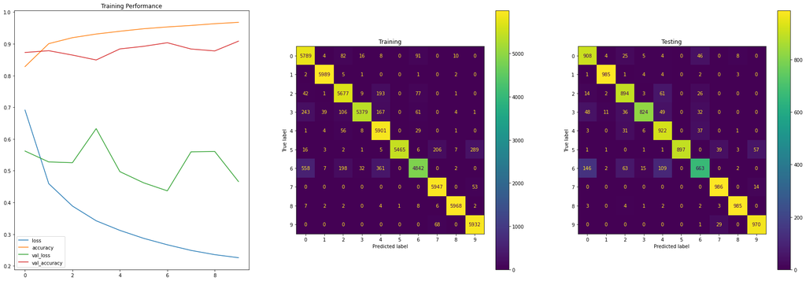

```python
inputs = Input(shape=(28, 28, 1, ), name='img')
x = resnet_v1(inputs, [32, 64, 128], 2, 7)
output = Dense(10)(x)
model_cnn = keras.Model(inputs=inputs, outputs=output, name='large_resnet_v1')
model_cnn.compile(loss=keras.losses.SparseCategoricalCrossentropy(from_logits=True),
              optimizer=keras.optimizers.RMSprop(),
              metrics=['accuracy'])
train_and_eval(model_cnn, x_train, y_train, x_test, y_test, 'resnet_v1_FashionMNIST_big.h5', batch_size, num_epochs)
```

### ResNet v2, Small Model

```
Epoch 00001: val_loss improved from inf to 1.16595, saving model to resnet_v2_FashionMNIST_small.h5
```

```
Epoch 00002: val_loss improved from 1.16595 to 0.97974, saving model to resnet_v2_FashionMNIST_small.h5
Epoch 00003: val_loss improved from 0.97974 to 0.65409, saving model to resnet_v2_FashionMNIST_small.h5
Epoch 00004: val_loss improved from 0.65409 to 0.47547, saving model to resnet_v2_FashionMNIST_small.h5
Epoch 00005: val_loss did not improve from 0.47547
Epoch 00006: val_loss did not improve from 0.47547
Epoch 00007: val_loss improved from 0.47547 to 0.43653, saving model to resnet_v2_FashionMNIST_small.h5
Epoch 00008: val_loss did not improve from 0.43653
Epoch 00009: val_loss did not improve from 0.43653
Epoch 00010: val_loss did not improve from 0.43653
```

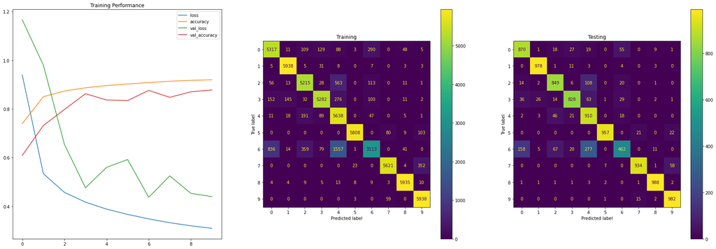

```python
inputs = Input(shape=(28, 28, 1, ), name='img')
x = resnet_v2(inputs, [16, 32], 2, 14)
output = Dense(10)(x)
model_cnn = keras.Model(inputs=inputs, outputs=output, name='simple_resnet_v2')
model_cnn.compile(loss=keras.losses.SparseCategoricalCrossentropy(from_logits=True),
              optimizer=keras.optimizers.RMSprop(),
              metrics=['accuracy'])
train_and_eval(model_cnn, x_train, y_train, x_test, y_test, 'resnet_v2_FashionMNIST_small.h5', batch_size, num_epochs)
```

### ResNet v2, Medium Model

```
Epoch 00001: val_loss improved from inf to 0.64790, saving model to resnet_v2_FashionMNIST_medium.h5
```

```
Epoch 00002: val_loss improved from 0.64790 to 0.53097, saving model to resnet_v2_FashionMNIST_medium.h5
Epoch 00003: val_loss improved from 0.53097 to 0.52021, saving model to resnet_v2_FashionMNIST_medium.h5
Epoch 00004: val_loss improved from 0.52021 to 0.49456, saving model to resnet_v2_FashionMNIST_medium.h5
Epoch 00005: val_loss improved from 0.49456 to 0.49193, saving model to resnet_v2_FashionMNIST_medium.h5
Epoch 00006: val_loss did not improve from 0.49193
Epoch 00007: val_loss did not improve from 0.49193
Epoch 00008: val_loss did not improve from 0.49193
Epoch 00009: val_loss improved from 0.49193 to 0.43557, saving model to resnet_v2_FashionMNIST_medium.h5
Epoch 00010: val_loss did not improve from 0.43557
```

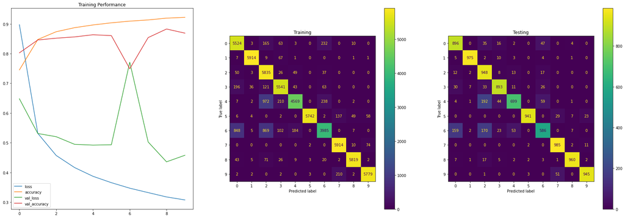

```python
inputs = Input(shape=(28, 28, 1, ), name='img')
x = resnet_v2(inputs, [8, 16, 32], 2, 7)
output = Dense(10)(x)
model_cnn = keras.Model(inputs=inputs, outputs=output, name='medium_resnet_v2')
model_cnn.compile(loss=keras.losses.SparseCategoricalCrossentropy(from_logits=True),
              optimizer=keras.optimizers.RMSprop(),
              metrics=['accuracy'])
train_and_eval(model_cnn, x_train, y_train, x_test, y_test, 'resnet_v2_FashionMNIST_medium.h5', batch_size, num_epochs)
```

### ResNet v2, Large Model

```
Epoch 00001: val_loss improved from inf to 1.04010, saving model to resnet_v2_FashionMNIST_big.h5
```

```
Epoch 00002: val_loss improved from 1.04010 to 1.03326, saving model to resnet_v2_FashionMNIST_big.h5
Epoch 00003: val_loss improved from 1.03326 to 0.76593, saving model to resnet_v2_FashionMNIST_big.h5
Epoch 00004: val_loss improved from 0.76593 to 0.62347, saving model to resnet_v2_FashionMNIST_big.h5
Epoch 00005: val_loss did not improve from 0.62347
Epoch 00006: val_loss did not improve from 0.62347
Epoch 00007: val_loss improved from 0.62347 to 0.51833, saving model to resnet_v2_FashionMNIST_big.h5
Epoch 00008: val_loss improved from 0.51833 to 0.45123, saving model to resnet_v2_FashionMNIST_big.h5
Epoch 00009: val_loss did not improve from 0.45123
Epoch 00010: val_loss did not improve from 0.45123
```

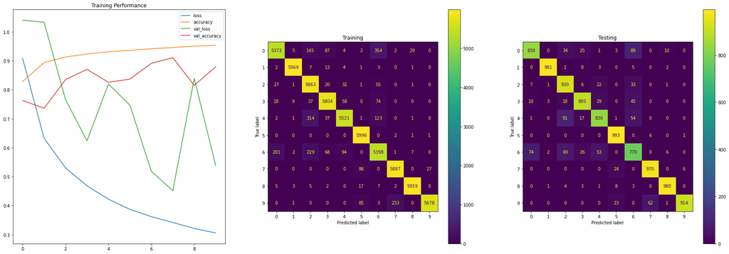

```python
inputs = Input(shape=(28, 28, 1, ), name='img')
x = resnet_v2(inputs, [32, 64, 128], 2, 7)
output = Dense(10)(x)
model_cnn = keras.Model(inputs=inputs, outputs=output, name='large_resnet_v2')
model_cnn.compile(loss=keras.losses.SparseCategoricalCrossentropy(from_logits=True),
              optimizer=keras.optimizers.RMSprop(),
              metrics=['accuracy'])
train_and_eval(model_cnn, x_train, y_train, x_test, y_test, 'resnet_v2_FashionMNIST_big.h5', batch_size, num_epochs)
```

## MNIST Models

```python
(x_train, y_train), (x_test, y_test) = keras.datasets.mnist.load_data()
x_train = x_train.reshape(x_train.shape[0], 28, 28, 1).astype('float32') / 255.0
y_train = y_train.reshape(y_train.shape[0], 1)
x_test = x_test.reshape(x_test.shape[0], 28, 28, 1).astype('float32') / 255.0
y_test = y_test.reshape(y_test.shape[0], 1)
```

### ResNet v1, Small Model

```
Epoch 00001: val_loss improved from inf to 0.53855, saving model to resnet_v1_MNIST_small.h5
```

```
Epoch 00002: val_loss improved from 0.53855 to 0.25274, saving model to resnet_v1_MNIST_small.h5
Epoch 00003: val_loss improved from 0.25274 to 0.17160, saving model to resnet_v1_MNIST_small.h5
Epoch 00004: val_loss improved from 0.17160 to 0.14468, saving model to resnet_v1_MNIST_small.h5
Epoch 00005: val_loss improved from 0.14468 to 0.11876, saving model to resnet_v1_MNIST_small.h5
Epoch 00006: val_loss did not improve from 0.11876
Epoch 00007: val_loss did not improve from 0.11876
Epoch 00008: val_loss did not improve from 0.11876
Epoch 00009: val_loss did not improve from 0.11876
Epoch 00010: val_loss did not improve from 0.11876
```

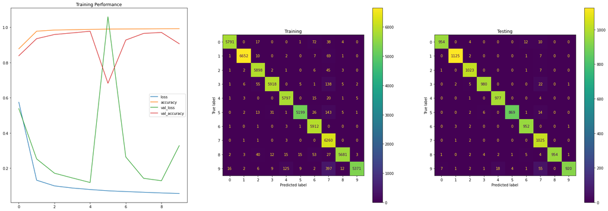

```python
inputs = Input(shape=(28, 28, 1, ), name='img')
x = resnet_v1(inputs, [16, 32], 2, 14)
output = Dense(10)(x)
model_cnn = keras.Model(inputs=inputs, outputs=output, name='simple_resnet_v1')
model_cnn.compile(loss=keras.losses.SparseCategoricalCrossentropy(from_logits=True),
              optimizer=keras.optimizers.RMSprop(),
              metrics=['accuracy'])
train_and_eval(model_cnn, x_train, y_train, x_test, y_test, 'resnet_v1_MNIST_small.h5', batch_size, num_epochs)
```

### ResNet v1, Medium Model

```
Epoch 00001: val_loss improved from inf to 0.74060, saving model to resnet_v1_MNIST_medium.h5
```

```
Epoch 00002: val_loss improved from 0.74060 to 0.20969, saving model to resnet_v1_MNIST_medium.h5
Epoch 00003: val_loss improved from 0.20969 to 0.15406, saving model to resnet_v1_MNIST_medium.h5
Epoch 00004: val_loss did not improve from 0.15406
Epoch 00005: val_loss did not improve from 0.15406
Epoch 00006: val_loss improved from 0.15406 to 0.11963, saving model to resnet_v1_MNIST_medium.h5
Epoch 00007: val_loss did not improve from 0.11963
Epoch 00008: val_loss did not improve from 0.11963
Epoch 00009: val_loss improved from 0.11963 to 0.10079, saving model to resnet_v1_MNIST_medium.h5
Epoch 00010: val_loss did not improve from 0.10079
```

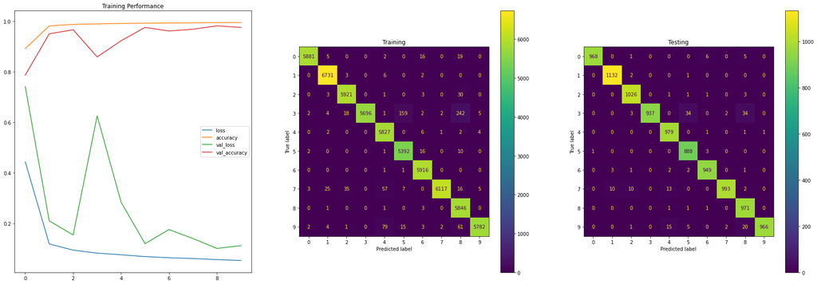

```python
inputs = Input(shape=(28, 28, 1, ), name='img')
x = resnet_v1(inputs, [8, 16, 32], 2, 7)
output = Dense(10)(x)
model_cnn = keras.Model(inputs=inputs, outputs=output, name='medium_resnet_v1')
model_cnn.compile(loss=keras.losses.SparseCategoricalCrossentropy(from_logits=True),
              optimizer=keras.optimizers.RMSprop(),
              metrics=['accuracy'])
train_and_eval(model_cnn, x_train, y_train, x_test, y_test, 'resnet_v1_MNIST_medium.h5', batch_size, num_epochs)
```

### ResNet v1, Large Model

```
Epoch 00001: val_loss improved from inf to 0.25042, saving model to resnet_v1_MNIST_big.h5
```

```
Epoch 00002: val_loss did not improve from 0.25042
Epoch 00003: val_loss improved from 0.25042 to 0.18310, saving model to resnet_v1_MNIST_big.h5
Epoch 00004: val_loss improved from 0.18310 to 0.15513, saving model to resnet_v1_MNIST_big.h5
Epoch 00005: val_loss did not improve from 0.15513
Epoch 00006: val_loss improved from 0.15513 to 0.09152, saving model to resnet_v1_MNIST_big.h5
Epoch 00007: val_loss did not improve from 0.09152
Epoch 00008: val_loss did not improve from 0.09152
Epoch 00009: val_loss did not improve from 0.09152
Epoch 00010: val_loss did not improve from 0.09152
```

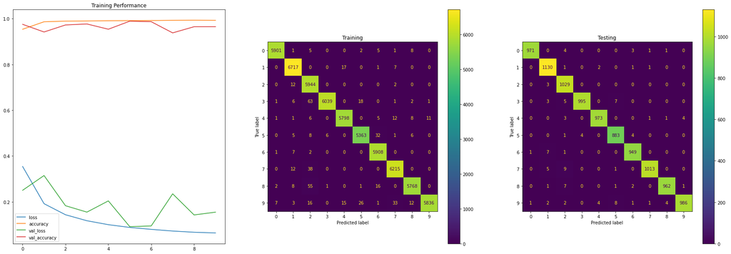

```python
inputs = Input(shape=(28, 28, 1, ), name='img')
x = resnet_v1(inputs, [32, 64, 128], 2, 7)
output = Dense(10)(x)
model_cnn = keras.Model(inputs=inputs, outputs=output, name='large_resnet_v1')
model_cnn.compile(loss=keras.losses.SparseCategoricalCrossentropy(from_logits=True),
              optimizer=keras.optimizers.RMSprop(),
              metrics=['accuracy'])
train_and_eval(model_cnn, x_train, y_train, x_test, y_test, 'resnet_v1_MNIST_big.h5', batch_size, num_epochs)
```

### ResNet v2, Small Model

```
Epoch 00001: val_loss improved from inf to 0.47633, saving model to resnet_v2_MNIST_small.h5
```

```
Epoch 00002: val_loss improved from 0.47633 to 0.26681, saving model to resnet_v2_MNIST_small.h5
Epoch 00003: val_loss improved from 0.26681 to 0.22496, saving model to resnet_v2_MNIST_small.h5
Epoch 00004: val_loss improved from 0.22496 to 0.17780, saving model to resnet_v2_MNIST_small.h5
Epoch 00005: val_loss did not improve from 0.17780
Epoch 00006: val_loss did not improve from 0.17780
Epoch 00007: val_loss did not improve from 0.17780
Epoch 00008: val_loss did not improve from 0.17780
Epoch 00009: val_loss did not improve from 0.17780
Epoch 00010: val_loss improved from 0.17780 to 0.16334, saving model to resnet_v2_MNIST_small.h5
```

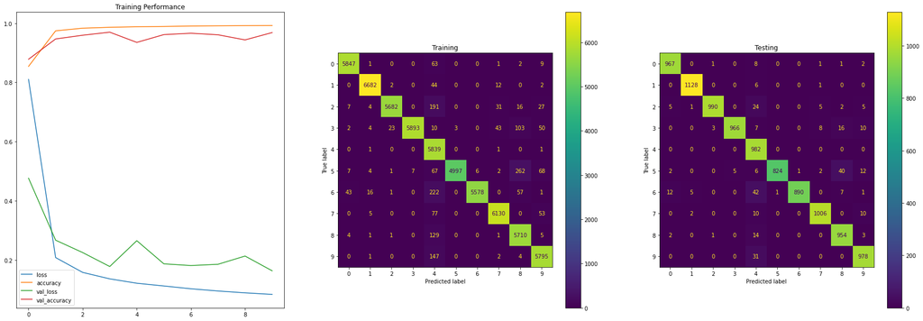

```python
inputs = Input(shape=(28, 28, 1, ), name='img')
x = resnet_v2(inputs, [16, 32], 2, 14)
output = Dense(10)(x)
model_cnn = keras.Model(inputs=inputs, outputs=output, name='simple_resnet_v2')
model_cnn.compile(loss=keras.losses.SparseCategoricalCrossentropy(from_logits=True),
              optimizer=keras.optimizers.RMSprop(),
              metrics=['accuracy'])
train_and_eval(model_cnn, x_train, y_train, x_test, y_test, 'resnet_v2_MNIST_small.h5', batch_size, num_epochs)
```

### ResNet v2, Medium Model

```
Epoch 00001: val_loss improved from inf to 0.32603, saving model to resnet_v2_MNIST_medium.h5
```

```
Epoch 00002: val_loss improved from 0.32603 to 0.23486, saving model to resnet_v2_MNIST_medium.h5
Epoch 00003: val_loss improved from 0.23486 to 0.14829, saving model to resnet_v2_MNIST_medium.h5
Epoch 00004: val_loss did not improve from 0.14829
Epoch 00005: val_loss did not improve from 0.14829
Epoch 00006: val_loss did not improve from 0.14829
Epoch 00007: val_loss improved from 0.14829 to 0.14351, saving model to resnet_v2_MNIST_medium.h5
Epoch 00008: val_loss improved from 0.14351 to 0.12906, saving model to resnet_v2_MNIST_medium.h5
Epoch 00009: val_loss improved from 0.12906 to 0.12004, saving model to resnet_v2_MNIST_medium.h5
Epoch 00010: val_loss did not improve from 0.12004
```

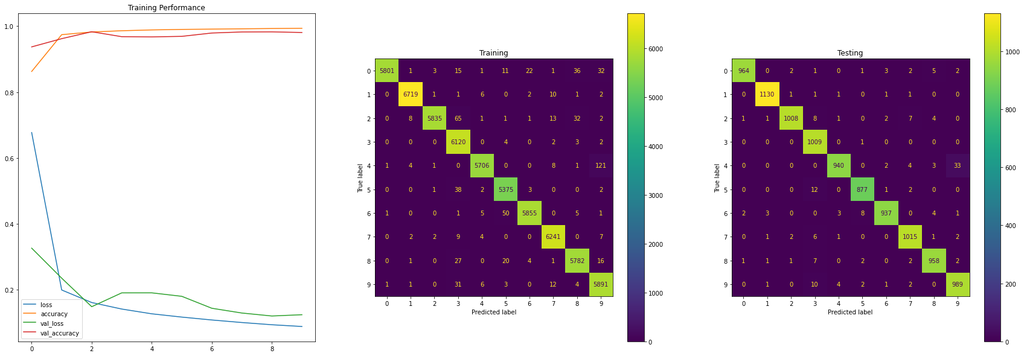

```python
inputs = Input(shape=(28, 28, 1, ), name='img')
x = resnet_v2(inputs, [8, 16, 32], 2, 7)
output = Dense(10)(x)
model_cnn = keras.Model(inputs=inputs, outputs=output, name='medium_resnet_v2')
model_cnn.compile(loss=keras.losses.SparseCategoricalCrossentropy(from_logits=True),
              optimizer=keras.optimizers.RMSprop(),
              metrics=['accuracy'])
train_and_eval(model_cnn, x_train, y_train, x_test, y_test, 'resnet_v2_MNIST_medium.h5', batch_size, num_epochs)
```

### ResNet v2, Large Model

```
Epoch 00001: val_loss improved from inf to 0.49768, saving model to resnet_v2_MNIST_big.h5
```

```
Epoch 00002: val_loss improved from 0.49768 to 0.46948, saving model to resnet_v2_MNIST_big.h5
Epoch 00003: val_loss improved from 0.46948 to 0.38453, saving model to resnet_v2_MNIST_big.h5
Epoch 00004: val_loss improved from 0.38453 to 0.21006, saving model to resnet_v2_MNIST_big.h5
Epoch 00005: val_loss did not improve from 0.21006
Epoch 00006: val_loss did not improve from 0.21006
Epoch 00007: val_loss did not improve from 0.21006
Epoch 00008: val_loss improved from 0.21006 to 0.13361, saving model to resnet_v2_MNIST_big.h5
Epoch 00009: val_loss improved from 0.13361 to 0.12384, saving model to resnet_v2_MNIST_big.h5
Epoch 00010: val_loss did not improve from 0.12384
```

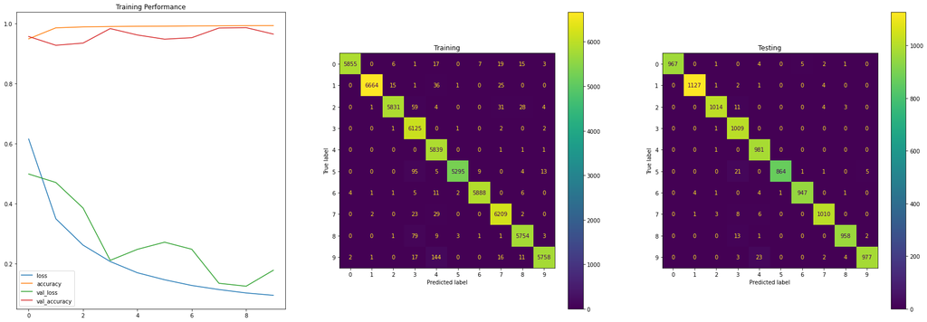

```python
inputs = Input(shape=(28, 28, 1, ), name='img')
x = resnet_v2(inputs, [32, 64, 128], 2, 7)
output = Dense(10)(x)
model_cnn = keras.Model(inputs=inputs, outputs=output, name='large_resnet_v2')
model_cnn.compile(loss=keras.losses.SparseCategoricalCrossentropy(from_logits=True),
              optimizer=keras.optimizers.RMSprop(),
              metrics=['accuracy'])
train_and_eval(model_cnn, x_train, y_train, x_test, y_test, 'resnet_v2_MNIST_big.h5', batch_size, num_epochs)
```

## CIFAR-10 Models

```python
(x_train, y_train), (x_test, y_test) = cifar10.load_data()
x_train = x_train.reshape(x_train.shape[0], 32, 32, 3) / 255.0
y_train = y_train.reshape(y_train.shape[0], 1)
x_test = x_test.reshape(x_test.shape[0], 32, 32, 3) / 255.0
y_test = y_test.reshape(y_test.shape[0], 1)
```

### ResNet v1, Small Model

```
Epoch 00001: val_loss improved from inf to 1.86856, saving model to resnet_v1_cifar_small.h5
```

```
Epoch 00002: val_loss improved from 1.86856 to 1.62458, saving model to resnet_v1_cifar_small.h5
Epoch 00003: val_loss did not improve from 1.62458
Epoch 00004: val_loss improved from 1.62458 to 1.20346, saving model to resnet_v1_cifar_small.h5
Epoch 00005: val_loss improved from 1.20346 to 1.12977, saving model to resnet_v1_cifar_small.h5
Epoch 00006: val_loss did not improve from 1.12977
Epoch 00007: val_loss did not improve from 1.12977
Epoch 00008: val_loss improved from 1.12977 to 1.02137, saving model to resnet_v1_cifar_small.h5
Epoch 00009: val_loss did not improve from 1.02137
Epoch 00010: val_loss did not improve from 1.02137
```

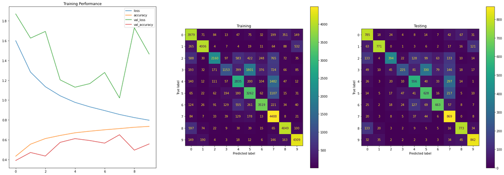

```python
inputs = Input(shape=(32, 32, 3, ), name='img')
x = resnet_v1(inputs, [16, 32], 2, 16)
output = Dense(10)(x)
model_cnn = keras.Model(inputs=inputs, outputs=output, name='simple_resnet_v1')
model_cnn.compile(loss=keras.losses.SparseCategoricalCrossentropy(from_logits=True),
              optimizer=keras.optimizers.RMSprop(),
              metrics=['accuracy'])
train_and_eval(model_cnn, x_train, y_train, x_test, y_test, 'resnet_v1_cifar_small.h5', batch_size, num_epochs)
```

### ResNet v1, Medium Model

```
Epoch 00001: val_loss improved from inf to 1.88712, saving model to resnet_v1_cifar_medium.h5
```

```
Epoch 00002: val_loss improved from 1.88712 to 1.53559, saving model to resnet_v1_cifar_medium.h5
Epoch 00003: val_loss improved from 1.53559 to 1.47151, saving model to resnet_v1_cifar_medium.h5
Epoch 00004: val_loss improved from 1.47151 to 1.34605, saving model to resnet_v1_cifar_medium.h5
Epoch 00005: val_loss did not improve from 1.34605
Epoch 00006: val_loss improved from 1.34605 to 1.19160, saving model to resnet_v1_cifar_medium.h5
Epoch 00007: val_loss did not improve from 1.19160
Epoch 00008: val_loss improved from 1.19160 to 1.12874, saving model to resnet_v1_cifar_medium.h5
Epoch 00009: val_loss did not improve from 1.12874
Epoch 00010: val_loss did not improve from 1.12874
```

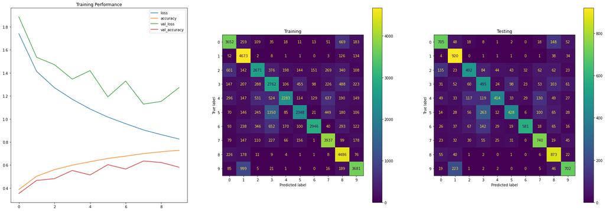

```python
inputs = Input(shape=(32, 32, 3, ), name='img')
x = resnet_v1(inputs, [8, 16, 32], 2, 8)
output = Dense(10)(x)
model_cnn = keras.Model(inputs=inputs, outputs=output, name='medium_resnet_v1')
model_cnn.compile(loss=keras.losses.SparseCategoricalCrossentropy(from_logits=True),
              optimizer=keras.optimizers.RMSprop(),
              metrics=['accuracy'])
train_and_eval(model_cnn, x_train, y_train, x_test, y_test, 'resnet_v1_cifar_medium.h5', batch_size, num_epochs)
```

### ResNet v1, Large Model

```
Epoch 00001: val_loss improved from inf to 1.55800, saving model to resnet_v1_cifar_big.h5
```

```
Epoch 00002: val_loss improved from 1.55800 to 1.32222, saving model to resnet_v1_cifar_big.h5
Epoch 00003: val_loss did not improve from 1.32222
Epoch 00004: val_loss did not improve from 1.32222
Epoch 00005: val_loss did not improve from 1.32222
Epoch 00006: val_loss did not improve from 1.32222
Epoch 00007: val_loss improved from 1.32222 to 1.24463, saving model to resnet_v1_cifar_big.h5
Epoch 00008: val_loss did not improve from 1.24463
Epoch 00009: val_loss did not improve from 1.24463
Epoch 00010: val_loss did not improve from 1.24463
```

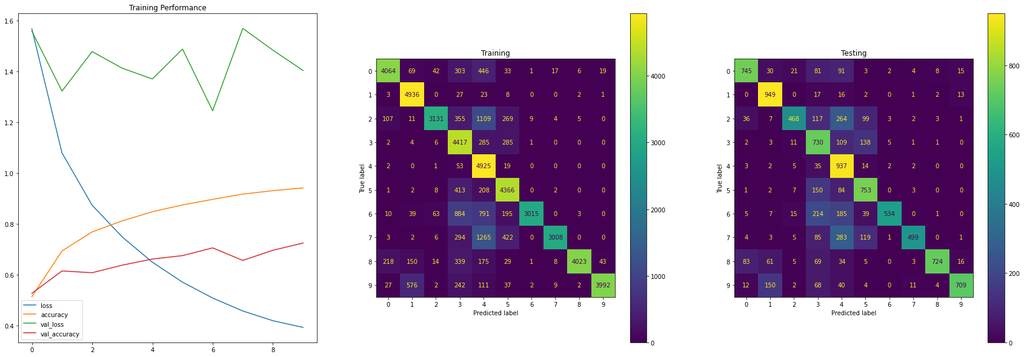

```python
inputs = Input(shape=(32, 32, 3, ), name='img')
x = resnet_v1(inputs, [32, 64, 128], 2, 8)
output = Dense(10)(x)
model_cnn = keras.Model(inputs=inputs, outputs=output, name='large_resnet_v1')
model_cnn.compile(loss=keras.losses.SparseCategoricalCrossentropy(from_logits=True),
              optimizer=keras.optimizers.RMSprop(),
              metrics=['accuracy'])
train_and_eval(model_cnn, x_train, y_train, x_test, y_test, 'resnet_v1_cifar_big.h5', batch_size, num_epochs)
```

### ResNet v2, Small Model

```
Epoch 00001: val_loss improved from inf to 1.60337, saving model to resnet_v2_cifar_small.h5
```

```
Epoch 00002: val_loss did not improve from 1.60337
Epoch 00003: val_loss improved from 1.60337 to 1.48268, saving model to resnet_v2_cifar_small.h5
Epoch 00004: val_loss did not improve from 1.48268
Epoch 00005: val_loss did not improve from 1.48268
Epoch 00006: val_loss improved from 1.48268 to 1.37183, saving model to resnet_v2_cifar_small.h5
Epoch 00007: val_loss did not improve from 1.37183
Epoch 00008: val_loss improved from 1.37183 to 1.12245, saving model to resnet_v2_cifar_small.h5
Epoch 00009: val_loss did not improve from 1.12245
Epoch 00010: val_loss did not improve from 1.12245
```

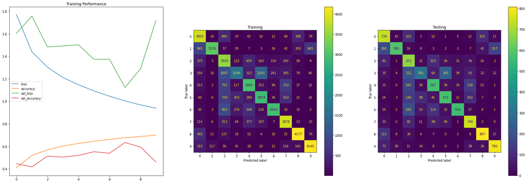

```python
inputs = Input(shape=(32, 32, 3, ), name='img')
x = resnet_v2(inputs, [16, 32], 2, 16)
output = Dense(10)(x)
model_cnn = keras.Model(inputs=inputs, outputs=output, name='simple_resnet_v2')
model_cnn.compile(loss=keras.losses.SparseCategoricalCrossentropy(from_logits=True),
              optimizer=keras.optimizers.RMSprop(),
              metrics=['accuracy'])
train_and_eval(model_cnn, x_train, y_train, x_test, y_test, 'resnet_v2_cifar_small.h5', batch_size, num_epochs)
```

### ResNet v2, Medium Model

```
Epoch 00001: val_loss improved from inf to 1.61554, saving model to resnet_v2_cifar_medium.h5
```

```
Epoch 00002: val_loss improved from 1.61554 to 1.48727, saving model to resnet_v2_cifar_medium.h5
Epoch 00003: val_loss did not improve from 1.48727
Epoch 00004: val_loss improved from 1.48727 to 1.37050, saving model to resnet_v2_cifar_medium.h5
Epoch 00005: val_loss improved from 1.37050 to 1.33165, saving model to resnet_v2_cifar_medium.h5
Epoch 00006: val_loss improved from 1.33165 to 1.20652, saving model to resnet_v2_cifar_medium.h5
Epoch 00007: val_loss did not improve from 1.20652
Epoch 00008: val_loss did not improve from 1.20652
Epoch 00009: val_loss did not improve from 1.20652
Epoch 00010: val_loss did not improve from 1.20652
```

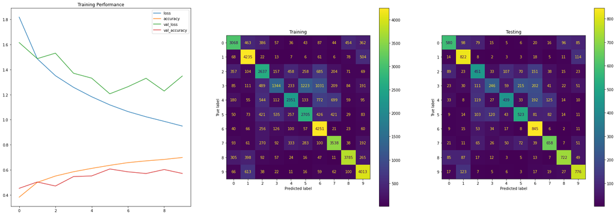

```python
inputs = Input(shape=(32, 32, 3, ), name='img')
x = resnet_v2(inputs, [8, 16, 32], 2, 8)
output = Dense(10)(x)
model_cnn = keras.Model(inputs=inputs, outputs=output, name='medium_resnet_v2')
model_cnn.compile(loss=keras.losses.SparseCategoricalCrossentropy(from_logits=True),
              optimizer=keras.optimizers.RMSprop(),
              metrics=['accuracy'])
train_and_eval(model_cnn, x_train, y_train, x_test, y_test, 'resnet_v2_cifar_medium.h5', batch_size, num_epochs)
```

### ResNet v2, Large Model

```
Epoch 00001: val_loss improved from inf to 2.84210, saving model to resnet_v2_cifar_big.h5
```

```
Epoch 00002: val_loss improved from 2.84210 to 1.43528, saving model to resnet_v2_cifar_big.h5
Epoch 00003: val_loss did not improve from 1.43528
Epoch 00004: val_loss improved from 1.43528 to 1.40554, saving model to resnet_v2_cifar_big.h5
Epoch 00005: val_loss did not improve from 1.40554
Epoch 00006: val_loss did not improve from 1.40554
Epoch 00007: val_loss improved from 1.40554 to 1.20509, saving model to resnet_v2_cifar_big.h5
Epoch 00008: val_loss did not improve from 1.20509
Epoch 00009: val_loss did not improve from 1.20509
Epoch 00010: val_loss did not improve from 1.20509
```

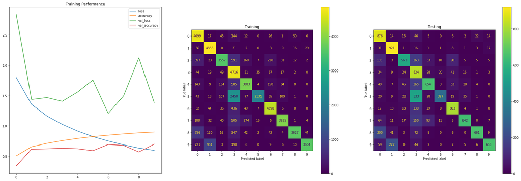

```python
inputs = Input(shape=(32, 32, 3, ), name='img')
x = resnet_v2(inputs, [32, 64, 128], 2, 8)
output = Dense(10)(x)
model_cnn = keras.Model(inputs=inputs, outputs=output, name='large_resnet_v2')
model_cnn.compile(loss=keras.losses.SparseCategoricalCrossentropy(from_logits=True),
              optimizer=keras.optimizers.RMSprop(),
              metrics=['accuracy'])
train_and_eval(model_cnn, x_train, y_train, x_test, y_test, 'resnet_v2_cifar_big.h5', batch_size, num_epochs)
```

## Final Thoughts

This script hasn't really been about explaining things, more just running a bunch of stuff. None the less it's worth briefly discussing the results, and the uses.

Firstly, the idea of this script is to train a bunch of models to later load and fine-tune for other tasks. Refer to the relevant examples regarding fine-tuning networks for further details on this.

With regards to results we see that:

- Bigger networks, with more filters and/or layers, do better; but the simpler networks are still pretty good.
- Generally, the "standard" configuration rather than the "bottleneck" configuration does a little bit better, but not much
- As noted above, the models here are not meant to be the best that is possible. Some of them do overfit slightly for example.